# Linearity: The rehearsal

Last updated in April 2021

## What linearity?

- People talk about linearity into two ways:
  - linear relationships between variables
  - linear forms of regression models

## Linear relationships

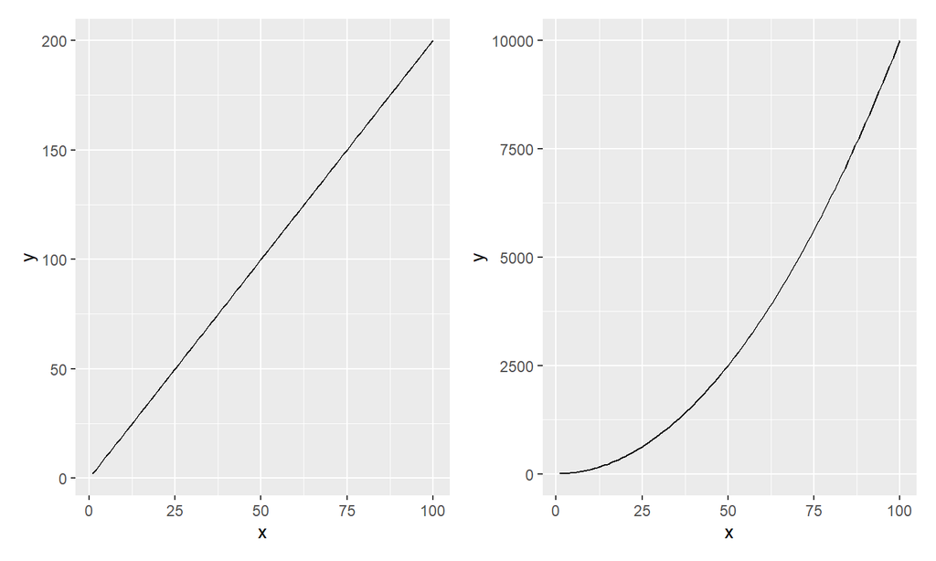

## Linear forms

- Linear forms

\(vote = \beta_0 + \beta_1 *age\)

\(vote = \beta_0 + \beta_1 *age + \beta_2*age^2\)

\(log(income) = \beta_0 + \beta_1 *log(age) + \beta_2*log(education)\)

- Nonlinear forms

\(price = \beta_0 + \frac{1}{\beta_1} * demand\)

\(income = \beta_0 + \beta_1*age^{\beta_2*education}\)

## Formal linearity

- Mathematically, linear regression assumes that the linear form can capture the relationships between variables
- e.g.:

\(log(income) = \beta_0 + \beta_1 *log(age) + \beta_2*log(education)\)

can capture the relationship between income, age and education (whether the relationship *between the raw variables* is linear or not)

- However just because your linear model can capture **a** nonlinear relationship, it won’t necessarily capture the correct relationship
- The residual plot basically tells you if the relationship between variables differs from the relationships assumed by your model